# Aufgabe

**Aufgabe und Daten**

- Für alle Projekte sind grundsätzlich alle Data Science-Phasen vorgesehen:
- Datenaufbereitung und Explorative Datenanalyse, speziell Visualisierung [20%]
- Modellierung (Klassifikation oder Regression) mit zumindest 3 Methoden, inkl. Parameter Tuning und Benchmarking [30%]
- Deployment des besten Modells mittels Webservice (und Webservice Test) [10%]
- Kurzpräsentation des Projekts/der Ergebnisse mittels Dashboards [10%]
- Zwei Extra-Features - zB neue Methoden, interaktive Visualisierungen [20%]
- Dokumentation und Einhaltung der Projekt-Richtlinien [10%]

# Datenvisualisierung

### Hauspreis nach Lage

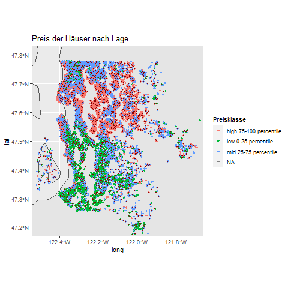

[figure not shown]

### Hauspreis nach Wohnfläche und Zustand

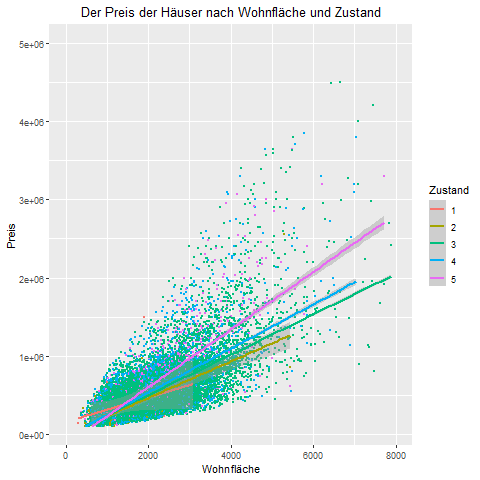

### Hauszustand nach Baujahren

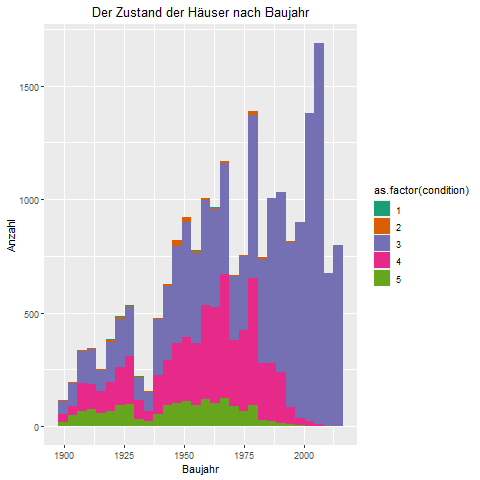

# Modelle

### Vorgangsweise

- Während der explorativen Datenanalyse wurden einige Datensätze gefunden, die nicht für die Analyse geeignet waren.
- Es wurde ein Datensatz mit unnatürlich hoher Anzahl an Zimmer (33) und nicht dazu passendem Preis entfernt, da es sich höchstwahrscheinlich um einen Eingabefehler handelt.
- Es wurde eine Korrelationsanalyse mittels einer Grafik durchgeführt, anhand derer einige Spalten verworfen wurden, da sie Kopien anderer Spalten darstellen oder nur sehr geringen Beitrag zur Erklärung von ‘price’ leisten: ’id, date, condition, yr_built, yr_renovated, zipcode, long, lat
- Die Daten wurden im nächsten Schritt in Trainings- und Testdaten unterteilt. Danach wurden 3 Modelle erstellt, die den Preis der Häuser anhand der anderen Variablen hervorsagen sollen. Es wurde ein Lineares-Regressionsmodell, ein Random-Forest-Modell und ein Neurales Netz verwendet.
- Anhand der Testdaten wurden der Root Mean Square Error (Wurzel des erwarteten quadratischen Abstands), *MAE* (Mittlere Absolute Fehler), *R2* Score, sowie *MAPE* (Mittlerer absoluter prozentualer Fehler) verglichen.
- Das beste Modell anhand des RMSE ist für diesen Datensatz das Random-Forest-Modell. Trotzdem muss dazu gesagt werden, dass wegen des sehr hohen RSMEs alle drei Modelle als schlecht einzustufen sind.

### Regressionsergebnisse aus dem Training

|  | RMSE | MAE | MAPE | R2 |
| --- | --- | --- | --- | --- |
| Random Forest | 198.735 | 125.189 | 26 | 0.71 |
| Lineare Regression | 222.890 | 150.094 | 31 | 0.6 |
| Neural Network | 648.249 | 539.0219 | 100 | -2.14 |

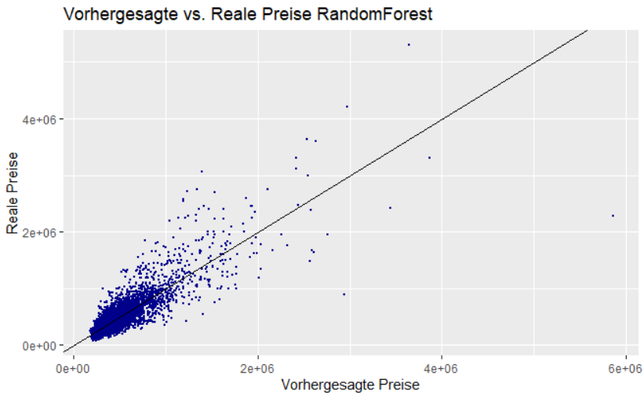

# Webservice

### Webservice

- Das beste Modell (Random Forest mit 101 Bäumen) wurde anschließend als Web service deployed.
- In Screenshots unten kann man 2 Test API Calls sehen:
  - Ein großes Haus mit vielen Zimmer, im guten Zustand und Grade mit Seeblick würde laut unserem Modell mehr als 2 Millionen US-Dollar kosten.
  - Ein kleiners Haus mit nur 2 Zimmer, im schlechten Zustand und Grade, mit keinem Seeblick würde laut unserem Modell weniger als 300 Tausend US-Dollar kosten.
- Anleitung zum Starten von Web Service:
  1. Starten Sie eine R session, und exekutieren Sie Kommandos in server_start.R
  2. Dadurch wird ein Web Service gestartet mit einem API Endpoint : POST http://127.0.0.1:8080/predict_price
  3. Starten Sie eine weitere R Session und probieren Sie die API aus, indem Sie Kommandos aus client_test.R exekutieren.

### Screenshot Vorhersage 1

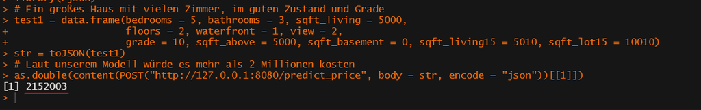

### Screenshot Vorhersage 2

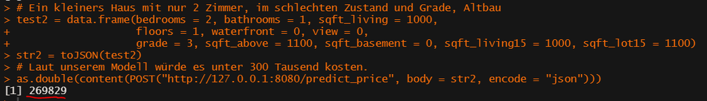

# Interaktive Grafiken

### Interaktive Grafiken

- Als zusätzliche Features wurde 2 interaktive Grafiken eingebaut (die als ShinyApp im Ordner /interactive liegen)
- Mit der ersten Grafik können Häuser dynamisch, anhand ihrer Preisklassen auf einer geograpfisch Karte filriert werden.
- Mit der zweiten Grafik können Korrelationen der dynamisch ausgewählten Merkmale der Häuser beobachtet werden. (Gut geeignet für explorative Datenanalyse)

### Screenshot Interaktive Grafik 1

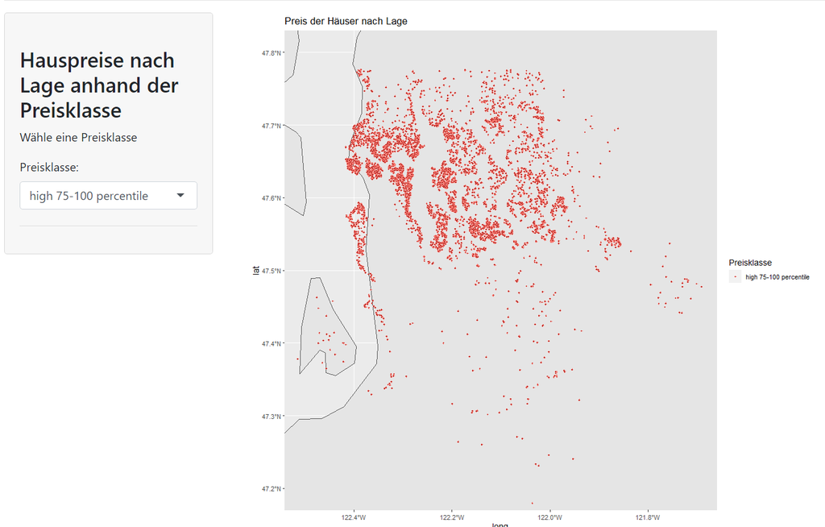

### Screenshot Interaktive Grafik 2

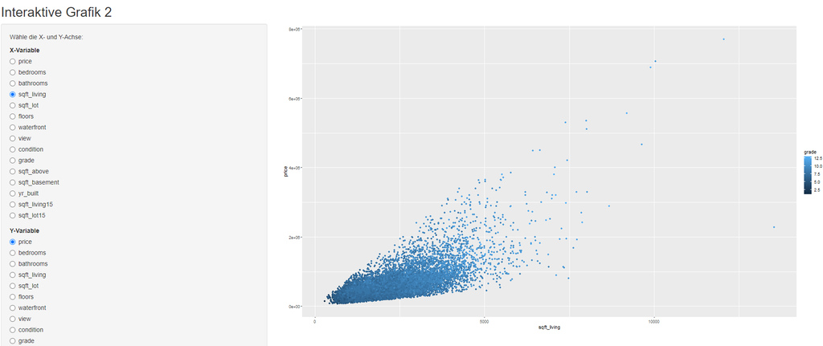